# Loan Default prediction for Lending Club

by Xuelin xuelin-amy@gmail.com

2020-03-08

*click `<code> icon` on the right corner to view the source code*

# 1 Background

**[Back to Home](https://xuelin-amy.github.io/playground/featured/)**

## 1.1 company

Lending Club is a peer to peer lending company based in the United States, in which investors provide funds for potential borrowers and investors earn a profit depending on the risk they take (the borrowers credit score). Lending Club provides the “bridge” between investors and borrowers. For more basic information about the company please check out the wikipedia article about the company.

## 1.2 task

SIB(Small Industries Bank) loans money to companies in exchange for the promise of repayment. Some will default on the loans, being unable to repay them for some reason. The bank maintains insurance to reduce their risk of loss in the event of default. The insured amount may cover all or just some part of the loan amount. SIB wants to predict which companies will default on their loans based on their financial information. They have provided you with a dataset that consists of loan related information such as loan amount, term, and state. Also, there is company information such as the number of employees, operating sector, etc.

Using machine learning, predict which companies will default on their loans and explain how different features impact the predictions.

# 2 Setup

**[Back to Home](https://xuelin-amy.github.io/playground/featured/)**

## 2.1 notebook setup

notebook setup to hide messages and warnings.

figure size was set to 4 x 2 inch.

set up ggplot theme for notebook.

```r
knitr::opts_chunk$set(warning = FALSE,
                      message = FALSE,
                      fig.height=2,
                      fig.width=4)

# set up theme for ggplot
my.theme <- theme(
  panel.background = element_rect(fill = "transparent"), # bg of the panel
  plot.background = element_rect(fill = "transparent"), # bg of the plot
  panel.grid.major = element_blank(), # get rid of major grid
  panel.grid.minor = element_blank(), # get rid of minor grid
  legend.background = element_rect(fill = "transparent", color = NA), # get rid of legend bg
  legend.box.background = element_rect(fill = "transparent", color = NA)) # get rid of legend panel
```

## 2.2 load packags

```r
library(data.table)
library(dplyr)
library(summarytools)
library(ggplot2)
library(ggpubr)
library(knitr)
library(kableExtra)
```

## 2.3 help functions

# 3 Data preparations

**[Back to Home](https://xuelin-amy.github.io/playground/featured/)**

## 3.1 data loading

there are two datasets:

- train.csv
- test.csv

In `train.csv`:

the first 6 rows of train.csv look like this:

```r
df <- fread('./data/train.csv')
df %>%
  select(-id) %>%
  head() %>%
  kable(caption = 'raw data') %>%
  kable_styling('striped',full_width = T)
```

raw data

| industry | state | request_date | term | employee_count | business_new | business_type | location | other_loans | loan_amount | insured_amount | default_status |
| --- | --- | --- | --- | --- | --- | --- | --- | --- | --- | --- | --- |
| Others | VA | 27-Apr-10 | 34 | 4 | New | 0 | Rural | N | $35,000.00 | $35,000.00 | 1 |
| Manufacturing | CA | 05-Nov-09 | 107 | 1 | New | 0 | Rural | N | $15,000.00 | $13,500.00 | 1 |
| Trading | CA | 26-Feb-10 | 84 | 1 | New | 0 | Rural | Y | $265,000.00 | $100,000.00 | 0 |
| Engineering | MI | 10-Jun-10 | 240 | 21 | New | 0 | Rural | N | $255,000.00 | $255,000.00 | 0 |
| Education | NH | 23-Sep-10 | 36 | 1 | Existing | 0 | Rural | N | $13,300.00 | $6,650.00 | 0 |
| Administration | VA | 24-Dec-09 | 60 | 42 | New | 0 | Rural | Y | $40,000.00 | $20,000.00 | 0 |

## 3.2 data cleansing

```r
clean_data <- function(df){
  df %>%
    mutate(
      request_date = as.Date(request_date, format = '%d-%B-%y'),
      loan_amount = as.numeric(gsub('[$,]','', loan_amount)),
      insured_amount = as.numeric(gsub('[$,]','', insured_amount)))
}
df <- clean_data(df)
df %>%
  select(-id) %>%
  head() %>%
  kable(caption = 'cleaned data') %>%
  kable_styling('striped',full_width = T)
```

cleaned data

| industry | state | request_date | term | employee_count | business_new | business_type | location | other_loans | loan_amount | insured_amount | default_status |
| --- | --- | --- | --- | --- | --- | --- | --- | --- | --- | --- | --- |
| Others | VA | 2010-04-27 | 34 | 4 | New | 0 | Rural | N | 35000 | 35000 | 1 |
| Manufacturing | CA | 2009-11-05 | 107 | 1 | New | 0 | Rural | N | 15000 | 13500 | 1 |
| Trading | CA | 2010-02-26 | 84 | 1 | New | 0 | Rural | Y | 265000 | 100000 | 0 |
| Engineering | MI | 2010-06-10 | 240 | 21 | New | 0 | Rural | N | 255000 | 255000 | 0 |
| Education | NH | 2010-09-23 | 36 | 1 | Existing | 0 | Rural | N | 13300 | 6650 | 0 |
| Administration | VA | 2009-12-24 | 60 | 42 | New | 0 | Rural | Y | 40000 | 20000 | 0 |

```r
NA
```

## 3.3 data summary

summary of `train.csv`

```r
df %>%
  select(-id) %>%
  dfSummary(style = 'grid', plain.ascii = F, tmp.img.dir = './tmp', headings = F)
```

| No | Variable | Stats / Values | Freqs (% of Valid) | Graph | Valid | Missing |
| --- | --- | --- | --- | --- | --- | --- |
| 1 | industry [character] | 1. Trading 2. Construction 3. Consulting 4. Hotel 5. Manufacturing 6. Healthcare 7. Others 8. Administration 9. Transportation 10. Agriculture [ 7 others ] | 508 (21.1%) 275 (11.4%) 267 (11.1%) 245 (10.2%) 245 (10.2%) 219 ( 9.1%) 168 ( 7.0%) 125 ( 5.2%) 106 ( 4.4%) 58 ( 2.4%) 186 ( 7.7%) | IIII II II II II I I I I | 2402 (100%) | 0 (0%) |
| 2 | state [character] | 1. CA 2. TX 3. NY 4. OH 5. FL 6. MN 7. WI 8. IL 9. UT 10. MA [ 40 others ] | 293 (12.2%) 191 ( 8.0%) 133 ( 5.5%) 102 ( 4.2%) 95 ( 4.0%) 91 ( 3.8%) 80 ( 3.3%) 79 ( 3.3%) 77 ( 3.2%) 74 ( 3.1%) 1187 (49.4%) | II I I IIIIIIIII | 2402 (100%) | 0 (0%) |
| 3 | request_date [Date] | min : 2009-10-01 med : 2010-03-11 max : 2010-09-30 range : 11m 29d | 271 distinct values | : : : . : : : . : : : : : : : . : : : : : : : : : : : : : : : : : : : : : : | 2402 (100%) | 0 (0%) |
| 4 | term [integer] | Mean (sd) : 87.6 (62.7) min < med < max: 1 < 84 < 312 IQR (CV) : 43 (0.7) | 155 distinct values | : : : : : . : : : : : : : . . | 2402 (100%) | 0 (0%) |
| 5 | employee_count [integer] | Mean (sd) : 9.3 (21.2) min < med < max: 0 < 4 < 500 IQR (CV) : 7 (2.3) | 88 distinct values | : : : : : | 2402 (100%) | 0 (0%) |
| 6 | business_new [character] | 1. Existing 2. New | 715 (29.8%) 1687 (70.2%) | IIIII IIIIIIIIIIIIII | 2402 (100%) | 0 (0%) |
| 7 | business_type [integer] | Min : 0 Mean : 0.1 Max : 1 | 0 : 2270 (94.5%) 1 : 132 ( 5.5%) | IIIIIIIIIIIIIIIIII I | 2402 (100%) | 0 (0%) |
| 8 | location [character] | 1. Rural | 2402 (100.0%) | IIIIIIIIIIIIIIIIIIII | 2402 (100%) | 0 (0%) |
| 9 | other_loans [character] | 1. N 2. Y | 1741 (72.5%) 661 (27.5%) | IIIIIIIIIIIIII IIIII | 2402 (100%) | 0 (0%) |
| 10 | loan_amount [numeric] | Mean (sd) : 204487.7 (364335.6) min < med < max: 100 < 50000 < 4e+06 IQR (CV) : 191492.5 (1.8) | 1031 distinct values | : : : : : . | 2402 (100%) | 0 (0%) |
| 11 | insured_amount [numeric] | Mean (sd) : 155016.7 (311422.7) min < med < max: 1700 < 35000 < 4e+06 IQR (CV) : 112250 (2) | 735 distinct values | : : : : : . | 2402 (100%) | 0 (0%) |
| 12 | default_status [integer] | Min : 0 Mean : 0.3 Max : 1 | 0 : 1629 (67.8%) 1 : 773 (32.2%) | IIIIIIIIIIIII IIIIII | 2402 (100%) | 0 (0%) |

# 4 Descriptive analysis

**[Back to Home](https://xuelin-amy.github.io/playground/featured/)**

## 4.1 term of loan

Compared with non-default loans, the default loans had relatively lower terms.

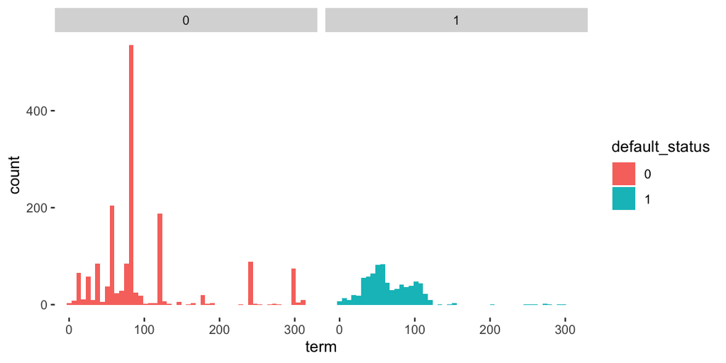

```r
# 4.1 term histogram
df %>%
  mutate(default_status = factor(default_status)) %>%
  ggplot(aes(x= term, fill= default_status)) +
  geom_histogram(bins=50) +
  facet_grid(~default_status) +
  my.theme
```

## 4.2 loan amount

### 4.2.1 distribution

Loan amount and Insured amount are both having skewed distribution. Logarithm transformation is applied to bring them to normal-like distribution.

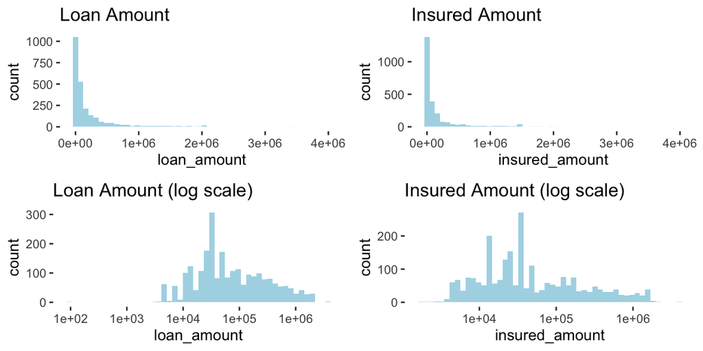

```r
p1 <- df %>%
  ggplot(aes(x=loan_amount)) +
  geom_histogram(bins = 50, fill='lightblue') +
  labs(title = 'Loan Amount') +
  my.theme
p2 <- df %>%
  ggplot(aes(x=insured_amount)) +
  geom_histogram(bins = 50, fill='lightblue') +
  labs(title = 'Insured Amount') +
  my.theme
p3 <- p1 + scale_x_log10() + labs(title = 'Loan Amount (log scale)')
p4 <- p2 + scale_x_log10() + labs(title = 'Insured Amount (log scale)')
ggarrange(p1,p2,p3,p4, ncol = 2, nrow = 2)
```

### 4.2.2 correlation

The insured amount for the default insurance is directly correlated with loan amount of the loan.

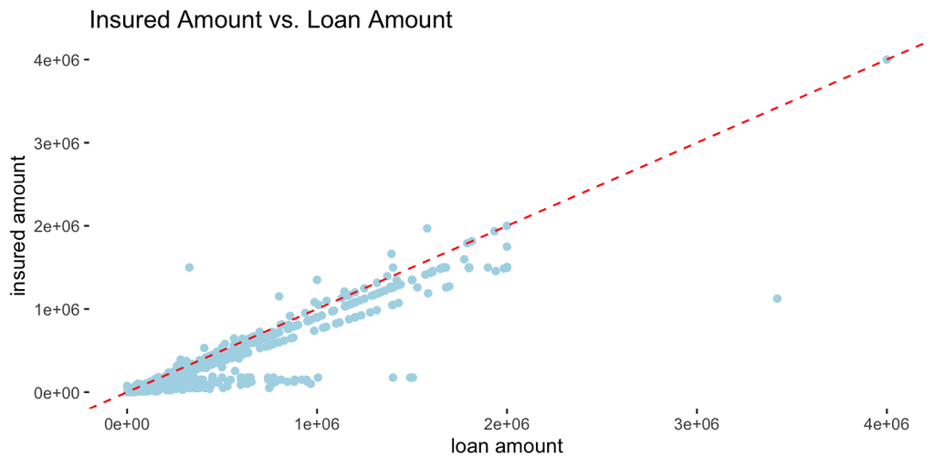

```r
df %>%
ggplot(aes(x = loan_amount, y = insured_amount)) +
geom_point(color = 'lightblue') +
geom_abline(slope = 1, intercept = 0, color = 'red', linetype = 'dashed') +
labs(title = 'Insured Amount vs. Loan Amount',
     x = 'loan amount',
     y = 'insured amount') +
  my.theme
```

### 4.2.3 effect on default

Lower loan amount tends to have high default rate

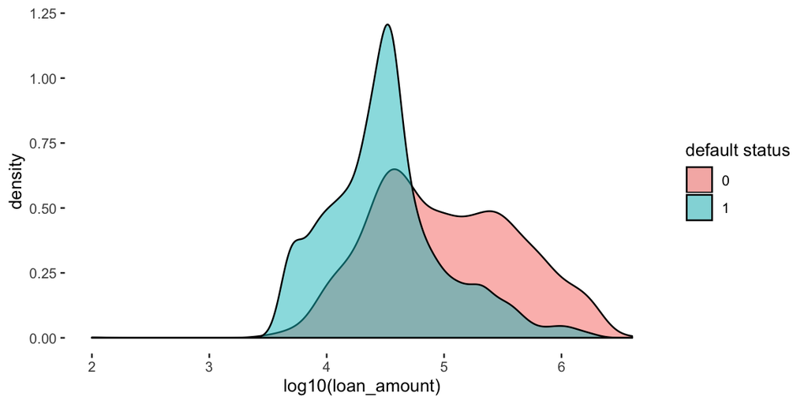

```r
# Loan Amount effect on default
df %>%
ggplot(aes(x = log10(loan_amount), fill = factor(default_status))) +
geom_density(alpha = 0.5) +
labs(fill = 'default status')+
  my.theme
```

## 4.3 default rate

### 4.3.1 by month

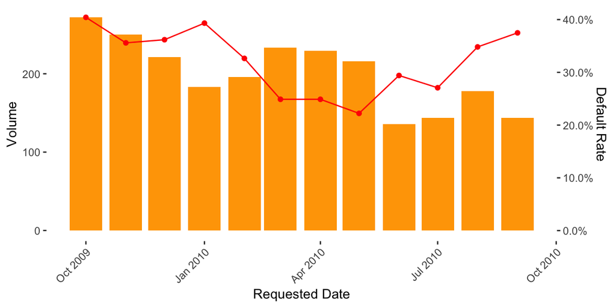

```r
res <- df %>%
  mutate(ym = format(request_date, '%Y-%m-01'),
         ym = as.Date(ym)) %>%
  group_by(ym) %>%
  summarise(volume = n(),
            default_rate = mean(default_status))
res %>%
  ggplot(aes(x= ym, y=volume)) +
  geom_bar(stat = 'identity', fill = 'orange', group= 1) +
  geom_line(aes(y = default_rate / max(res$default_rate) * max(res$volume)), stat = 'identity', color='red', group = 1) +
  geom_point(aes(y = default_rate / max(res$default_rate) * max(res$volume)), stat = 'identity', color='red', group = 1) +
  scale_y_continuous(labels = function(i) format(i, big.mark = ','),
                     sec.axis = sec_axis(~./max(res$volume) * max(res$default_rate),
                                         labels = scales::percent,
                                         name = 'Default Rate'
                                         )) +
  scale_x_date()+
  labs(x='Requested Date',y='Volume') +
  my.theme +
  theme(axis.text.x = element_text(angle = 45, hjust = 1))
```

- bars represent the volume of loans in each month
- line represents the default rate in each month

### 4.3.2 by industry

Construction industry has highest default rate, while energy industry has the lowest

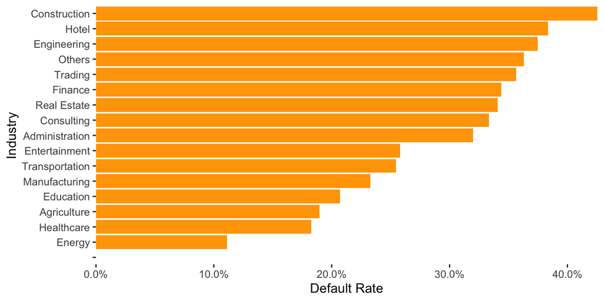

```r
df %>%
  group_by(industry) %>%
  summarise(default_rate= mean(default_status)) %>%
  ggplot(aes(x=reorder(industry, default_rate), y=default_rate)) +
  geom_bar(stat = 'identity', fill='orange') +
  scale_y_continuous(labels = scales::percent) +
  labs(x='Industry', y='Default Rate') +
  coord_flip(expand = F)  +
  my.theme
```

### 4.3.3 by business type

New business tends to have higher default rate

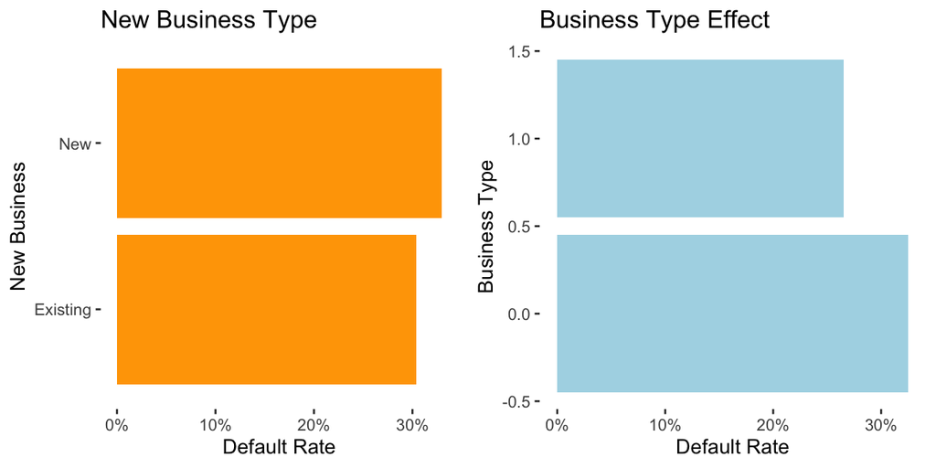

```r
p1 <- df %>%
  group_by(business_new) %>%
  summarise(default_rate = mean(default_status)) %>%
  ggplot(aes(x=business_new, y=default_rate)) +
  geom_bar(stat = 'identity', fill='orange') +
  scale_y_continuous(labels=scales::percent) +
  labs(title = 'New Business Type', x='New Business',y='Default Rate') +
  coord_flip() +
  my.theme

p2 <- df %>%
  group_by(business_type) %>%
  summarise(default_rate = mean(default_status)) %>%
  ggplot(aes(x = business_type, y = default_rate)) +
  geom_bar(stat = 'identity', fill = 'lightblue') +
  scale_y_continuous(labels = scales::percent) +
  labs(title = 'Business Type Effect', x = 'Business Type', y = 'Default Rate') +
  coord_flip() +
  my.theme

ggarrange(p1,p2, ncol = 2)
```

# 5 Predictive modelling

**[Back to Home](https://xuelin-amy.github.io/playground/featured/)**

## 5.1 Preparations

### 5.1.1 Merge train/test set

Combining train & test data for data cleansing and feature engineering.

```r
## combine train and valid before convert to factor

df$flag <- 'train'
df.test <- fread('./data/test.csv') %>%
  clean_data() %>%
  mutate(default_status = 0, flag='test')
df.full <-rbind(df,df.test)

#creat features from request data
df.full <- df.full %>%
  mutate(request_ym = format(request_date, '%Y-%m'))
```

### 5.1.2 Launch H2O and set up

```r
# init h2o library
library(h2o)
h2o.init(nthreads = 4, max_mem_size = '4g')
```

```
 Connection successful!

R is connected to the H2O cluster:
    H2O cluster uptime:         2 minutes 47 seconds
    H2O cluster timezone:       Asia/Shanghai
    H2O data parsing timezone:  UTC
    H2O cluster version:        3.26.0.2
    H2O cluster version age:    7 months and 10 days !!!
    H2O cluster name:           H2O_started_from_R_xuelin_tms177
    H2O cluster total nodes:    1
    H2O cluster total memory:   1.77 GB
    H2O cluster total cores:    4
    H2O cluster allowed cores:  4
    H2O cluster healthy:        TRUE
    H2O Connection ip:          localhost
    H2O Connection port:        54321
    H2O Connection proxy:       NA
    H2O Internal Security:      FALSE
    H2O API Extensions:         Amazon S3, XGBoost, Algos, AutoML, Core V3, Core V4
    R Version:                  R version 3.6.1 (2019-07-05)
```

```r
h2o.no_progress()
#convert data.table to h2o.frame
full.hex <- as.h2o(df.full)

#convert categorical variables to factor
full.hex$label <- h2o.asfactor(full.hex$default_status)
full.hex$industry <- h2o.asfactor(full.hex$industry)
full.hex$state <- h2o.asfactor(full.hex$state)
full.hex$business_new <- h2o.asfactor(full.hex$business_new)
full.hex$other_loans <- h2o.asfactor(full.hex$other_loans)
full.hex$request_ym <- h2o.asfactor(full.hex$request_ym)

#split train, test
train.hex <- full.hex[full.hex$flag == 'train',]
test.hex <- full.hex[full.hex$flag == 'test',]

#define feature set
feature.names <- c('industry','state','term','employee_count','request_ym','business_new',
                   'business_type', 'other_loans','loan_amount','insured_amount')
```

## 5.2 Baseline: Logisitc Regression

### 5.2.1 model performance

```r
# 5.1 Linear Model- Logistic Regression Baseline
model_ridge <- h2o.glm(x=feature.names, y='label',
                       training_frame = train.hex,
                       family = 'binomial',
                       nfolds = 5, alpha = 0, lambda_search = T)

# auc
res_ridge <- h2o.auc(model_ridge, train=T, xval = T)
```

AUC of ROC - Logistic regression

- train set: 0.81
- valid set: 0.78

train history:

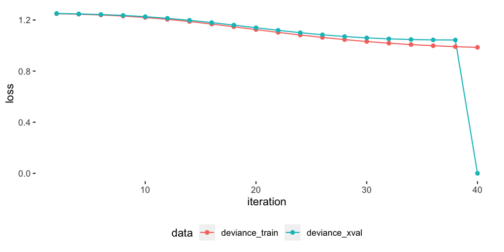

```r
model_ridge@model$scoring_history %>%
  select(iteration, deviance_train, deviance_xval) %>%
  tidyr::pivot_longer(cols = -iteration,
                      names_to = 'data',
                      values_to = 'loss') %>%
  ggplot(aes(x = iteration, y = loss, color = data)) +
  geom_line() +
  geom_point() +
  my.theme +
  theme(legend.position = 'bottom')
```

### 5.2.2 variable importance

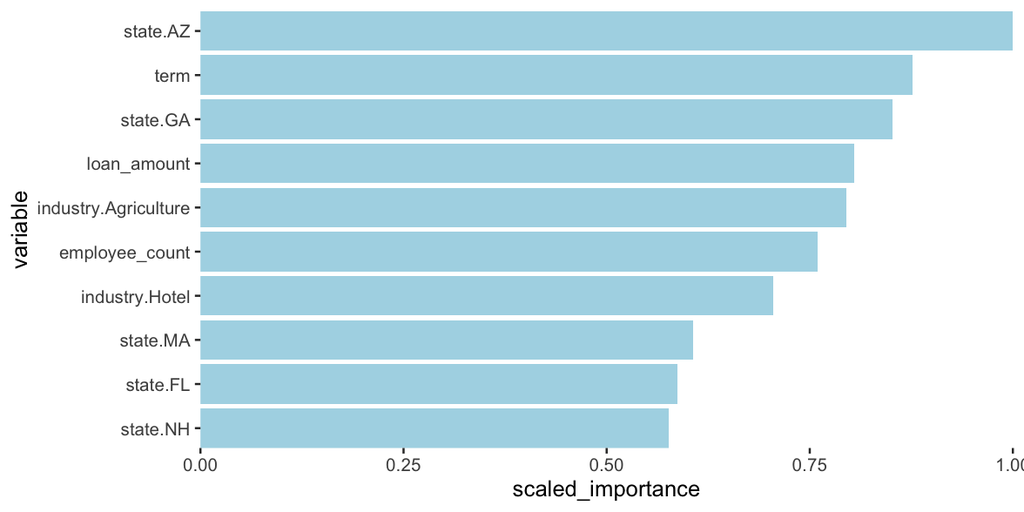

```r
h2o.varimp(model_ridge) %>%
head(10) %>%
ggplot(aes(x = reorder(variable, scaled_importance), y = scaled_importance)) +
geom_bar(stat = 'identity', fill = 'lightblue') +
coord_flip(expand = F) +
labs(x = 'variable')+
my.theme
```

```r
h2o.varimp(model_ridge) %>% head(10) %>%
  kable(caption = 'Logistic Regression Variable Importance') %>%
  kable_styling('striped')
```

Logistic Regression Variable Importance

| variable | relative_importance | scaled_importance | percentage |
| --- | --- | --- | --- |
| state.AZ | 0.9324776 | 1.0000000 | 0.0400847 |
| term | 0.8169718 | 0.8761302 | 0.0351194 |
| state.GA | 0.7939451 | 0.8514361 | 0.0341296 |
| loan_amount | 0.7502973 | 0.8046277 | 0.0322533 |
| industry.Agriculture | 0.7413452 | 0.7950274 | 0.0318684 |
| employee_count | 0.7084459 | 0.7597458 | 0.0304542 |
| industry.Hotel | 0.6575193 | 0.7051314 | 0.0282650 |
| state.MA | 0.5651523 | 0.6060760 | 0.0242944 |
| state.FL | 0.5474091 | 0.5870480 | 0.0235316 |
| state.NH | 0.5375559 | 0.5764813 | 0.0231081 |

## 5.3 Xgboost model

```r
# 5.2 Xgboost Model -Tree Based Ensemble Model
model_xgb <- h2o.xgboost(x=feature.names,y='label',
                         training_frame = train.hex,
                         max_depth = 6, eta = 0.1,
                         stopping_metric = 'AUC',stopping_rounds = 21,
                         ntrees = 500, nfolds = 5)
#auc
res_xgboost <- h2o.auc(model_xgb, train = T, xval = T)
```

### 5.3.1 model performance

AUC of ROC - Xgboost

- train set: 1
- valid set: 0.95

train history:

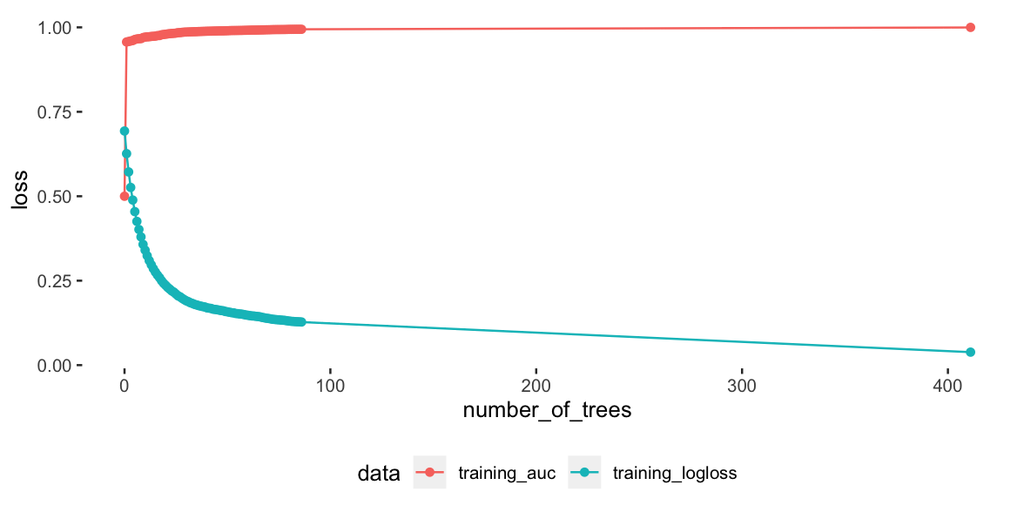

```r
model_xgb@model$scoring_history %>%
  select(number_of_trees, training_logloss, training_auc) %>%
  tidyr::pivot_longer(cols = -number_of_trees,
                      names_to = 'data',
                      values_to = 'loss') %>%
  ggplot(aes(x = number_of_trees, y = loss, color = data)) +
  geom_line() +
  geom_point() +
  my.theme +
  theme(legend.position = 'bottom')
```

### 5.3.2 variable importance

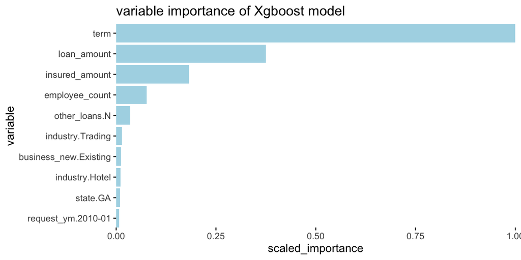

```r
h2o.varimp(model_xgb) %>%
head(10) %>%
ggplot(aes(x = reorder(variable, scaled_importance), y = scaled_importance)) +
geom_bar(stat = 'identity', fill = 'lightblue') +
coord_flip(expand = F) +
labs(title = 'variable importance of Xgboost model', x = 'variable') + my.theme
```

```r
h2o.varimp(model_xgb) %>% head(10) %>%
  kable(caption = 'Xgboost Variable Importance') %>%
  kable_styling('striped')
```

Xgboost Variable Importance

| variable | relative_importance | scaled_importance | percentage |
| --- | --- | --- | --- |
| term | 7935.17871 | 1.0000000 | 0.5450172 |
| loan_amount | 2975.59180 | 0.3749874 | 0.2043746 |
| insured_amount | 1447.49463 | 0.1824149 | 0.0994192 |
| employee_count | 602.33594 | 0.0759070 | 0.0413706 |
| other_loans.N | 275.76093 | 0.0347517 | 0.0189403 |
| industry.Trading | 109.14555 | 0.0137546 | 0.0074965 |
| business_new.Existing | 91.52952 | 0.0115347 | 0.0062866 |
| industry.Hotel | 87.39921 | 0.0110141 | 0.0060029 |
| state.GA | 75.84157 | 0.0095576 | 0.0052091 |
| request_ym.2010-01 | 56.33741 | 0.0070997 | 0.0038695 |

## 5.4 Model selection

### 5.4.1 make prediction

Let’s view the sample of predictions from xgboost model.

*caveat: a threshold of 0.5 was assumed to output the prediction class*

xgboost model prediction

| id | p0 | p1 | predict |
| --- | --- | --- | --- |
| 0 | 0.46 | 0.54 | default |
| 0 | 1.00 | 0.00 | repaid |
| 0 | 0.99 | 0.01 | repaid |
| 0 | 0.72 | 0.28 | repaid |
| 0 | 1.00 | 0.00 | repaid |
| 0 | 0.02 | 0.98 | default |
| 0 | 0.93 | 0.07 | repaid |
| 0 | 1.00 | 0.00 | repaid |
| 0 | 0.01 | 0.99 | default |
| 0 | 1.00 | 0.00 | repaid |